# Assignment 5

Indigo Bannister & Gavriella Keyles

12/4/2019

### Introduction

Pacific giant salamanders (*Dicamptodon tenebrosus*), the largest terrestrial salamander in North America, thrive in the wet forests of coastal northern California, Oregon, and Washington (California Herps, 2019). Their preferred habitat is near clear, cold streams, rivers, lakes, or ponds with rocks, logs or root channels to burrow under. Larvae hatch under water and spend approximately the first two years of their lives in the water. Once they transform to their terrestrial forms, reproduction also occurs in the water, (California Herps, 2019). Due to their sensitivity to water quality, Pacific giant salamanders are used as an indicator species of the declining health of waterways. Logging can be particularly impactful on Pacific giant salamanders due to the increased sedimentation of streams from erosion (Oregon Wild, 2019).

Oregon State University has been monitoring the species along Mack Creek in the H.J. Andrews Experimental Forest near Eugene, Oregon since 1993. Electrofishing is used to capture vertebrates along the creek and all captured vertebrates are measured and weighed (Gregory S. V., 2016). The Mack Creek watershed (1,433 acres) contains two unique management histories: approximately 13% of the watershed was clear cut around 1963 and the rest contains a 500-year-old coniferous forest (Andrews Experimental Forest, 2017). This research forest offers a unique chance to consider the long-term impacts of logging on salamander well-being compared to a more natural forest.

In this analysis, we use data provided by the Andrews Experimental Forest to explore differences in salamander abundance and weight among old growth and clear-cut sections of Mack Creek and among different stream characteristics (pool, cascade, side channel).

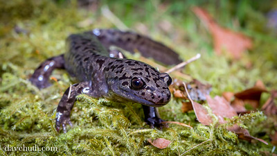

**Figure 1:** Pacific Giant Salamander (Dicamptodon tenebrosus), in Opal Creek Wilderness, Oregon. Photographer: [Dave Huth](https://www.flickr.com/photos/davemedia/9094499321).

### Data & methods

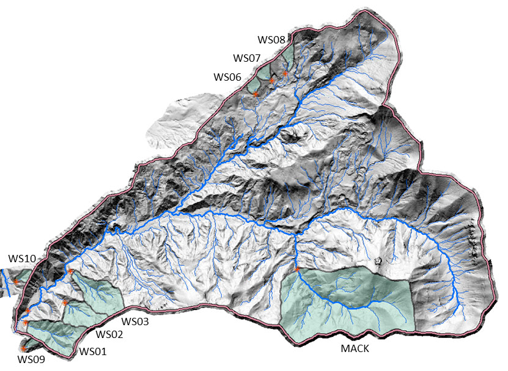

**Figure 2:** Map of HJ Andrews Forest Experimental Watersheds - Mack Creek watershed highlighted in green. Source: [HJ Andrews Experimental Forest](https://andrewsforest.oregonstate.edu/research/infrastructure/watersheds).

Data for populations of Pacific Giant Salamanders *(Dicamptodon tenebrosus)* were collected in the [H.J. Andrews Experimental Forest](https://andrewsforest.oregonstate.edu/) near Blue River, Oregon as part of the National Science Foundation’s Long Term Ecological Research Network. Salamanders were sampled with two-pass electrofishing in two sections of Mack Creek, one reach in a section of clearcut forest (ca. 1963) and the other an upstream 500-year-old coniferous forest. The two sections are then subdivided to indicate where in the channel salamanders were found (pool, cascade, or side-channel). According to project metadata, the purpose of the Aquatic Vertebrate Population Study in Mack Creek, is “to provide a long-term record of populations in aquatic vertebrates…related to land use and disturbance histories.”

For more information see the project [metadata](https://portal.lternet.edu/nis/metadataviewer?packageid=knb-lter-and.4027.12)

All analyses and figures were prepared using R software version 3.6.1.

### Results

#### 1. Salamander counts in various sections of Mack Creek

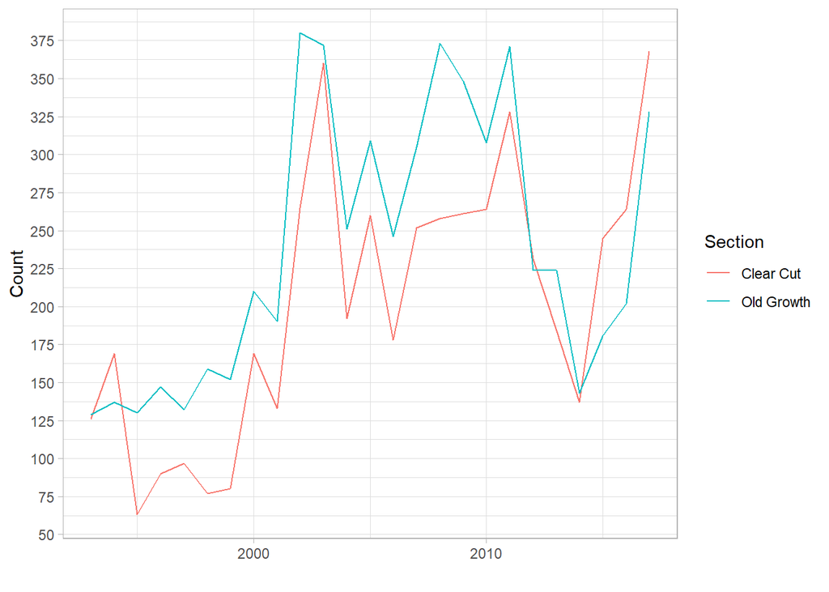

#### 2. 2017 Salamander counts by channel classification

*Table 1:* *2017 counts of Salamanders found in Mack Creek, grouped by section (clear cut vs. old growth) and position within channel (pool, cascades, side-channel).*

[output not shown]

#### 3. Chi-square test to assess association between forest section and channel classification in 2017

We used a Chi-square test to examine the relationship between channel position (pool, side-channel or cascades) and section (clear cut or old growth) in Mack Creek. We found a *X*<sup>2</sup> value of 5.54 (d.f. 2) with a p-value of 0.063. As a result, we retain the null hypothesis that there is *no* association between channel position and forest section for Pacific giant salamanders in Mack Creek.

#### 5. One-way ANOVA to explore differences in salamander weights by channel classification

```
##                Df Sum Sq Mean Sq F value Pr(>F)
## channel_class   2    757   378.4   4.216 0.0151 *
## Residuals     684  61403    89.8
## ---
## Signif. codes:  0 '***' 0.001 '**' 0.01 '*' 0.05 '.' 0.1 ' ' 1
## 1 observation deleted due to missingness
```

```
##   Tukey multiple comparisons of means
##     95% family-wise confidence level
##
## Fit: aov(formula = weight ~ channel_class, data = salamander_weight_2017)
##
## $channel_class
##                            diff        lwr        upr     p adj
## Pool-Cascades          1.776650 -0.9846147  4.5379145 0.2862119
## Side-Channel-Cascades -1.844204 -3.8759182  0.1875106 0.0841989
## Side-Channel-Pool     -3.620854 -6.7089770 -0.5327303 0.0166225
```

### References

**Andrews Experimental Forest. 2017.** [Location Name: Andrews Mack Creek Watershed.](http://andlter.forestry.oregonstate.edu/data/place.aspx?domain=place&dbcode=HF004&placeid=669) HJ Andrews Experimental Forest Long-Term Ecological Research.

**California Herps. 2019.** [Coastal Giant Salamander - *Dicamptodon tenebrosus*.](http://www.californiaherps.com/salamanders/pages/d.tenebrosus.html)

**Gregory S. V. 2016.** [Aquatic Vertebrate Population Study in Mack Creek, Andrews Experimental Forest, 1987 to present.](https://doi.org/10.6073/pasta/5de64af9c11579266ef20da2ff32f702) Environmental Data Initiative. Dataset accessed 11/19/2019.

**Oregon Wild. 2019.** [Pacific Giant Salamander.](https://oregonwild.org/wildlife/pacific-giant-salamander)